# Exploratory Analysis of Train Data for Data Science Capstone

Harland Hendricks

November 27, 2018

## Executive Summary

This report will walk you through the exploratory analysis of my training dataset for the Johns Hopkins University Data Science Capstone. The training dataset is only a fraction of the raw data (20%) to keep the size manageable when creating larger n-gram dfms.

With a training data set of just over 850K observations and 20M words, there are some interesting insights:

- Twitter is a majority of the observations
- There is one observation that contains almost 1800 words
- Characters per observation drops significantly after 140 characters (which happens to be the character limit for Twitter)
- “just” and “like” are used a lot in blogs and Twitter; they are also in the top 5 overall
- “rt” is in the top 50 overall, which isn’t a word and could mean many things (Russian Times, right, rount trip, etc.)

Next I will build a prediction algorithm with a Markov or MLE model based on my research online. This can always change as I watch the course videos. I will also build a Shiny App that takes a user input of three words and shows the next predicted word from the model.

## Train Dataset Creation

The instructions for this assignment are located [here.](https://www.coursera.org/learn/data-science-project/peer/BRX21/milestone-report)

Built with R version 3.5.0 with the following system:

```
##           sysname           release           version          nodename
##         "Windows"          "10 x64"     "build 17134" "DESKTOP-TPCQ5AJ"
##           machine             login              user    effective_user
##          "x86-64"           "harla"           "harla"           "harla"
```

For this portion of the project I used the libraries readr, caret, quanteda, and ggplot2

Since this assignment focuses on the exploratory analysis of the dataset, I have chosen not to display any of the code used to get and clean the data.

The process I used can be summed up in the following:

- Downloaded the data [here.](https://d396qusza40orc.cloudfront.net/dsscapstone/dataset/Coursera-SwiftKey.zip)
- Brought data into R as data frames
- Combined the three data frames into one data frame with the following added columns:
  - $label - Factor that identifies origin for line (blog, news, or twitter)
  - $nchar - Number of characters in each line
  - $words - Number of words in each line
- Took a 20% sample using $label as the proportion for sample
- Created a corpus and created a function that tokenized with the following attributes:
  - Tokenized into words
  - Removed symbols
  - Removed numbers
  - Removed punctuation
  - Removed profanity as defined by [Google](https://www.freewebheaders.com/download/files/full-list-of-bad-words_text-file_2018_07_30.zip)
- Created unigram dfm with stopwords removed, since I wanted to explore the non-stopwords

## Exploratory Data Analysis of the Train Dataset

Structure of train.data demonstrating the column names and type of data

```
## 'data.frame':    853937 obs. of  4 variables:
##  $ label: Factor w/ 3 levels "blog","news",..: 1 1 1 1 1 1 1 1 1 1 ...
##  $ text : chr  "If I were a bear," "I am en-route to Cornwall again. 3/4 months of slog and sun and sea too. Always a job needs doing in a tourist "| __truncated__ "People like you are unknowing transformers of things, protected by your own fairy-tale, by love.”" "The one thing that was astoundin…
##  $ nchar: int  17 298 97 412 207 779 23 255 27 213 ...
##  $ words: int  5 58 15 79 44 139 5 44 4 29 ...
```

Tables to show number of lines for each label and ratio to the whole train dataset (document source: blog, news, or twitter)

```
##
##    blog    news twitter
##  179858  202049  472030
```

```
##
##      blog      news   twitter
## 0.2106221 0.2366088 0.5527691
```

Summary of number of characters variable that shows range of values

```
##    Min. 1st Qu.  Median    Mean 3rd Qu.    Max.
##     1.0    44.0    88.0   133.8   153.0 11384.0
```

Summary of number of words variable that shows range of values

```
##    Min. 1st Qu.  Median    Mean 3rd Qu.    Max.
##    1.00    8.00   16.00   23.88   27.00 1792.00
```

Number of words in the train dataset (not unique words)

```
## [1] 20387895
```

Bar chart showing proportion of labels

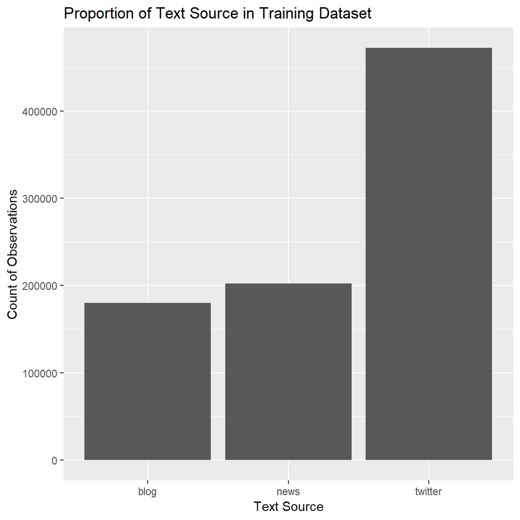

Histogram of Train Dataset by Number of Characters

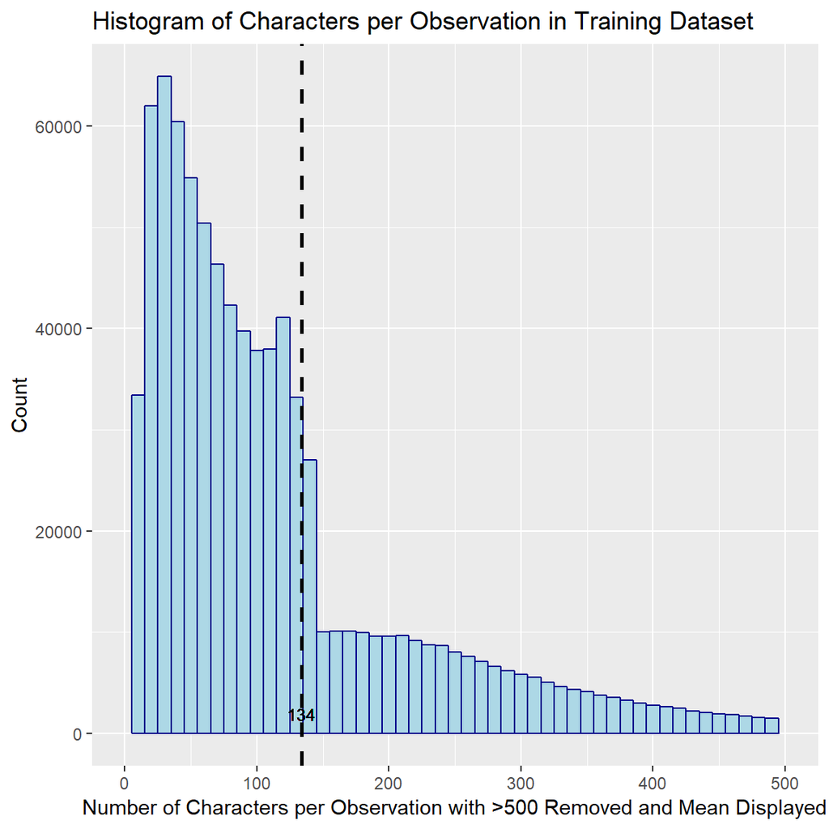

Histogram of Train Dataset by Number of Words

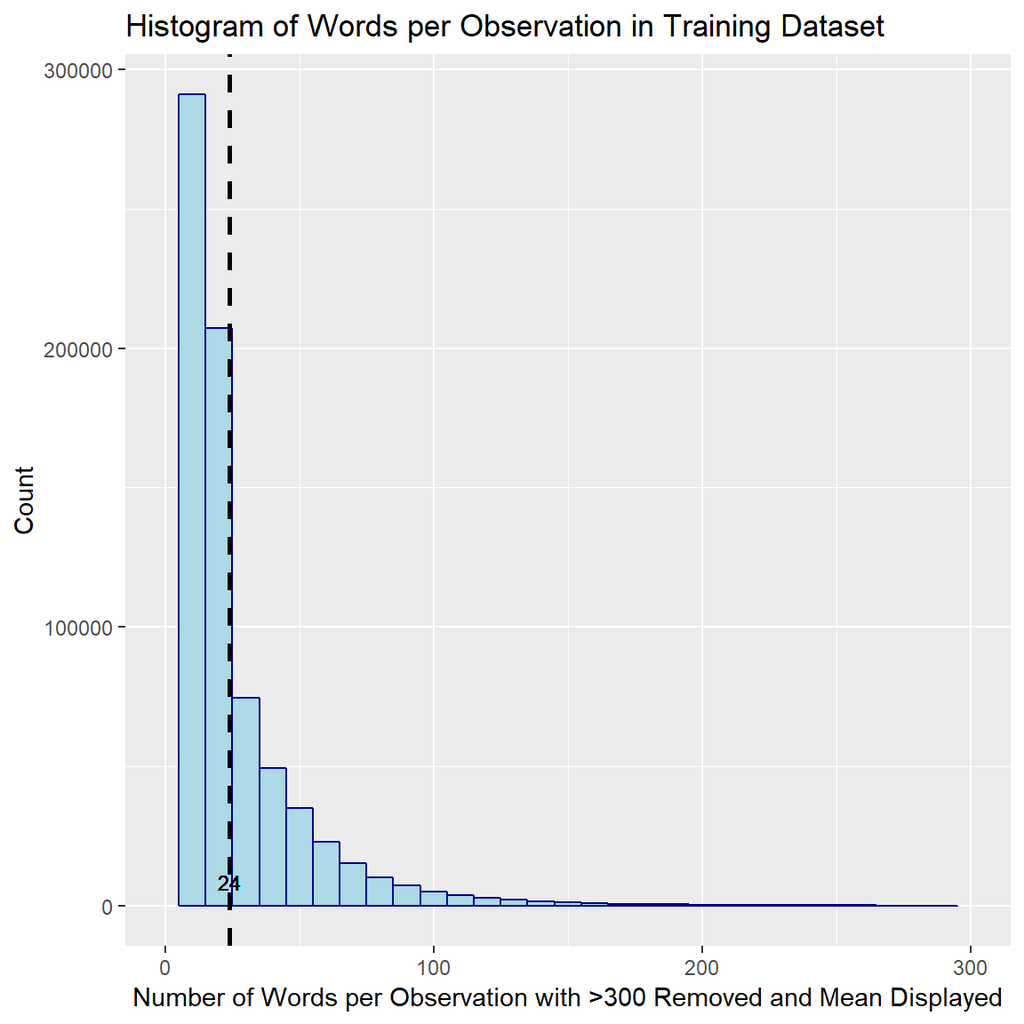

Plot frequency of top 50 words from dfm with stopwords removed

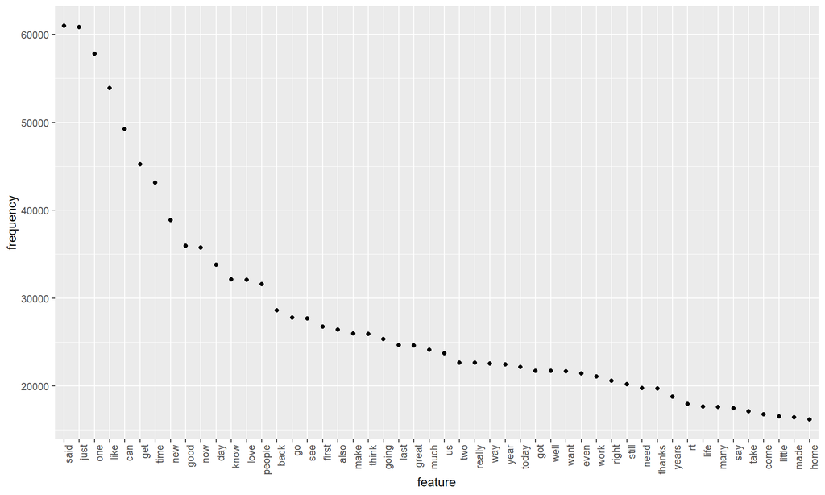

List of top 50 words per $label from dfm with stopwords removed (blog, news, twitter)

```
##  [1] "one"       "just"      "like"      "can"       "time"
##  [6] "get"       "now"       "also"      "know"      "people"
## [11] "even"      "make"      "first"     "back"      "see"
## [16] "new"       "much"      "well"      "think"     "good"
## [21] "way"       "really"    "day"       "us"        "little"
## [26] "go"        "love"      "two"       "going"     "many"
## [31] "life"      "still"     "things"    "made"      "want"
## [36] "said"      "last"      "work"      "something" "right"
## [41] "take"      "years"     "around"    "say"       "may"
## [46] "got"       "great"     "never"     "need"      "year"
```

```
##  [1] "said"    "one"     "new"     "also"    "two"     "can"     "year"
##  [8] "just"    "last"    "first"   "time"    "years"   "like"    "state"
## [15] "people"  "get"     "now"     "city"    "three"   "back"    "make"
## [22] "says"    "even"    "many"    "school"  "home"    "way"     "good"
## [29] "game"    "going"   "made"    "may"     "day"     "county"  "still"
## [36] "much"    "work"    "percent" "team"    "go"      "since"   "season"
## [43] "take"    "police"  "think"   "million" "say"     "well"    "another"
## [50] "u.s"
```

```
##  [1] "just"    "like"    "get"     "love"    "good"    "thanks"  "day"
##  [8] "can"     "rt"      "now"     "one"     "know"    "time"    "great"
## [15] "today"   "go"      "lol"     "new"     "see"     "u"       "back"
## [22] "got"     "going"   "think"   "need"    "people"  "happy"   "us"
## [29] "want"    "make"    "right"   "much"    "follow"  "tonight" "really"
## [36] "come"    "work"    "night"   "thank"   "well"    "still"   "way"
## [43] "last"    "best"    "hope"    "oh"      "never"   "life"    "say"
## [50] "next"
```

### Exploratory Analysis Insights

Exploring the data reveals the following:

- There are over 850K observations in the sample with over 20M words
- Twitter is a majority of the observations
- There is one observation that contains almost 1800 words
- Characters per observation drops significantly after 140 characters (which happens to be the character limit for Twitter)
- “just” and “like” are used a lot in blogs and Twitter; they are also in the top 5 overall
- “rt” is in the top 50 overall, which isn’t a word and could mean many things (Russian Times, right, rount trip, etc.)

## Next Steps with Prediction Algorithm and Shiny App

My plan is to use a Markov or MLE mode with n-grams to build the prdiction algorithm, but I haven’t watched the material for model building yet. I just did a bit of research online.

For the Shinny App I will have user input for three words of a sentence and the model will predict the following word.